# SI 370 - Homework #2: Data Visualization

Version 2023.09.20.1.CT

For this homework assignment, you will use a dataset similar to one we used in an earlier lecture: the small MovieLens dataset, available via https://files.grouplens.org/datasets/movielens/ml-latest-small.zip. Download that file to get the data, and also take some time to go through the [README](https://files.grouplens.org/datasets/movielens/ml-latest-small-README.html) file.

Be sure to download your own copy of the dataset -- do not rely on data that you may have downloaded for a previous assignment.

A major challenge for you in this assignment is to devise a plan to tackle each question. The question states the overall goal, and in some cases hints are provided, but you will need to think carefully about what data you need to answer each of the questions. We will go over some planning in class together so you get a feel for what you need to do.

Each of the questions is worth the same number of points. Points will be allocated according to the following rubric:

- 90-100%: Question is correctly and completely answered. Answer consists of well-written code that conforms to [PEP 8](https://www.python.org/dev/peps/pep-0008/) guidelines and is accompanied by a written interpretation in a Markdown block. Written interpretation does not contain spelling, grammar or stylistic errors (see [Strunk & White](https://drive.google.com/file/d/1L0P7xJwjUGBvyb49mL3dw1Bt7hzRTiTl/view?usp=sharing) for a detailed specifications). Minor problems, such as formatting, incorrect submissions, missing names, etc. will result in less than 100%.
- 75-85% : Answer is mostly complete and correct; two or fewer noticeable omissions or errors. Minor stylistic flaws, either in code or in written interpretation.
- 50-70%: Answer has significant omissions or errors; Noticeable departure from PEP-8 guildelines and/or moderate spelling, grammar, or style issues in written interpretations.
- 25-45%: Question is perfunctorily attempted. Substantial parts are missing or incorrect.
- 0 points: Question not attempted.

**NOTE**: You are only permitted to use the pandas, Seaborn, and matplotlib libraries for creating visualizations in this assignment. You may use other libraries for other purposes, but you may not use them to create visualizations.

First, let's do our usual imports (you might need to import additional modules depending on how you choose to tackle each question):

```python
import pandas as pd
import seaborn as sns
import matplotlib.pyplot as plt
import numpy as np
```

And let's read the data (note: you might need to include path information if the data files are not in the same directory as this notebook):

```python
movies = pd.read_csv('~/Downloads/ml-latest-small/movies.csv')
ratings = pd.read_csv('~/Downloads/ml-latest-small/ratings.csv')
tags = pd.read_csv('~/Downloads/ml-latest-small/tags.csv')
```

```python
movies
```

|  | movieId | title | genres |
| --- | --- | --- | --- |
| 0 | 1 | Toy Story (1995) | Adventure\|Animation\|Children\|Comedy\|Fantasy |
| 1 | 2 | Jumanji (1995) | Adventure\|Children\|Fantasy |
| 2 | 3 | Grumpier Old Men (1995) | Comedy\|Romance |
| 3 | 4 | Waiting to Exhale (1995) | Comedy\|Drama\|Romance |
| 4 | 5 | Father of the Bride Part II (1995) | Comedy |
| ... | ... | ... | ... |
| 9737 | 193581 | Black Butler: Book of the Atlantic (2017) | Action\|Animation\|Comedy\|Fantasy |
| 9738 | 193583 | No Game No Life: Zero (2017) | Animation\|Comedy\|Fantasy |
| 9739 | 193585 | Flint (2017) | Drama |
| 9740 | 193587 | Bungo Stray Dogs: Dead Apple (2018) | Action\|Animation |
| 9741 | 193609 | Andrew Dice Clay: Dice Rules (1991) | Comedy |

9742 rows × 3 columns

### Q1:

Using the `movies` DataFrame, create a visualization that shows the number of movies for each decade from the 1900s to the 2010s. Use the number in parentheses (e.g. (1975)) at the end of the title as the year. Drop all rows that do not have a valid year.

**Hint**: The year is always the middle 4 characters of the last 6 characters of the title. You can use the `str` accessor to extract the year from the title.

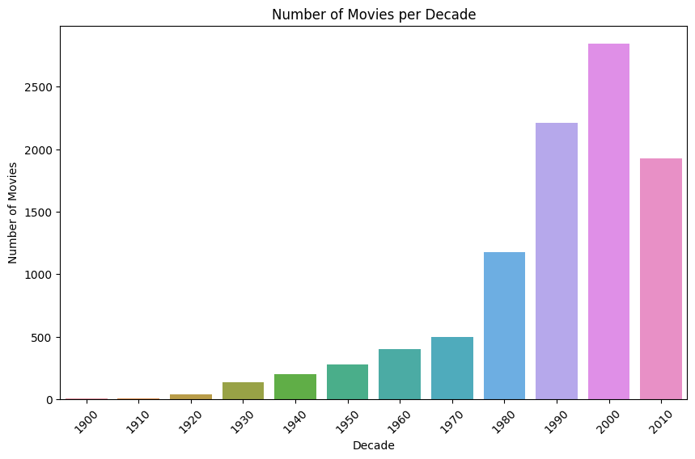

```python
movies['year'] = movies['title'].str[-5:-1]

movies['year'] = pd.to_numeric(movies['year'], errors='coerce')
movies = movies.dropna(subset=['year'])
movies['year'] = movies['year'].astype(int)


movies['decade'] = (movies['year'] // 10) * 10

decade_counts = movies.groupby('decade').size().reset_index(name='number_of_movies')

plt.figure(figsize=(10,6))
sns.barplot(x='decade', y='number_of_movies', data=decade_counts)
plt.title('Number of Movies per Decade')
plt.xlabel('Decade')
plt.ylabel('Number of Movies')
plt.xticks(rotation=45)
plt.show()
```

### Q2:

Create a visualization that shows the number of movies in each genre.

**Hint**: the `pd.DataFrame.explode()` function might be useful here.

Be sure that your axis labels are legible!

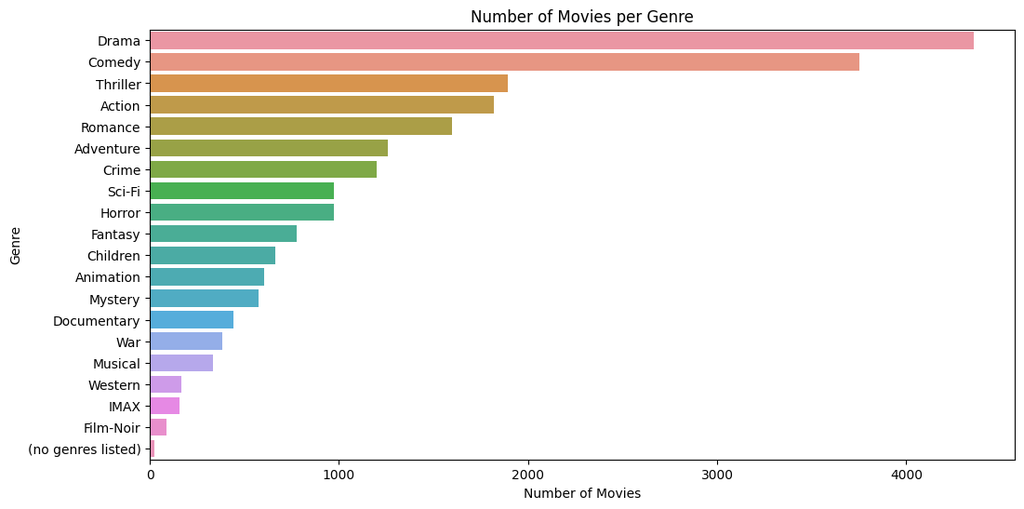

```python
movies = movies.dropna(subset=['genres'])

movies = movies[movies['genres'].apply(lambda x: isinstance(x, str))]

movies['genres'] = movies['genres'].str.split('|')
movies_exploded = movies.explode('genres')

genre_counts = movies_exploded['genres'].value_counts().reset_index()
genre_counts.columns = ['genre', 'number_of_movies']

plt.figure(figsize=(12,6))
sns.barplot(x='number_of_movies', y='genre', data=genre_counts)
plt.title('Number of Movies per Genre')
plt.xlabel('Number of Movies')
plt.ylabel('Genre')
plt.show()
```

### Q3a:

Create a visualization showing the distribution of the values from the `rating` column of the `ratings` DataFrame.

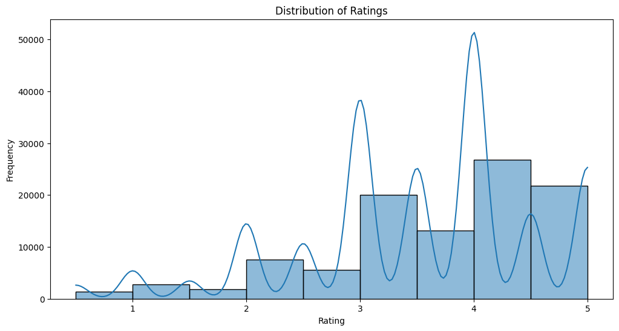

```python
plt.figure(figsize=(12,6))

sns.histplot(ratings['rating'], kde=True, bins=9)

plt.title('Distribution of Ratings')
plt.xlabel('Rating')
plt.ylabel('Frequency')

plt.show()
```

### Q3b:

What do you notice about the relative number of whole-number ratings (1,2,3,4,and 5) compared to the half-ratings (0.5, 1.5, 2.5, 3.5, 4.5)? Investigate the data further to see if you can figure out why that's the case. (Hint: a scatterplot showing the ratings vs. time might be helpful.)

We can see that when the ratings are whole numbers, there is a much higher volume of frequencies. When looking at the data more clearly, we can see that whenever there is a whole number rating, the line on the bar graph spikes indicating that there are far more ratings that are whole numbers, than ratings that are half numbers.

### Q4:

Write code to confirm the assertion that the ratings ["were created by 610 users between March 29, 1996 and September 24, 2018."](https://files.grouplens.org/datasets/movielens/ml-latest-small-README.html).

```python
unique_users = ratings['userId'].nunique()
print(f'Number of Unique Users: {unique_users}')
ratings['timestamp'] = pd.to_datetime(ratings['timestamp'], unit='s')
min_time = ratings['timestamp'].min()
max_time = ratings['timestamp'].max()
print(f'Time Range of Ratings: {min_time} to {max_time}')
```

```
Number of Unique Users: 610
Time Range of Ratings: 1996-03-29 18:36:55 to 2018-09-24 14:27:30
```

### Q5:

Create a visualization showing the number of ratings produced on each day of the week.

Hint: the `pd.to_datetime()` function might be useful here, as well as the `dt` accessor.

Make sure your axis labels are in a reasonable order.

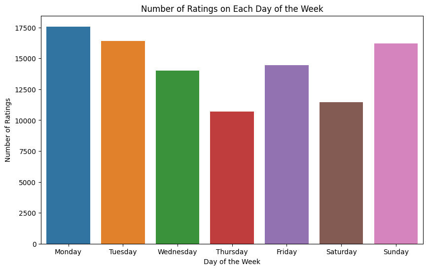

```python
ratings['timestamp'] = pd.to_datetime(ratings['timestamp'], unit='s')
ratings['day_of_week'] = ratings['timestamp'].dt.day_name()

ratings_per_day = ratings['day_of_week'].value_counts(sort=False).reindex(['Monday', 'Tuesday', 'Wednesday', 'Thursday', 'Friday', 'Saturday', 'Sunday'])

plt.figure(figsize=(10,6))

sns.barplot(x=ratings_per_day.index, y=ratings_per_day.values)

plt.title('Number of Ratings on Each Day of the Week')
plt.xlabel('Day of the Week')
plt.ylabel('Number of Ratings')

plt.show()
```

### Q6a:

Create a new column called `taglength` in the `tags` DataFrame that contains the number of **characters** in the tag.

**Hint:** the `str.len()` function might be useful here.

```python
tags['taglength'] = tags['tag'].str.len()

print(tags.head(3))
```

```
   userId  movieId              tag   timestamp  taglength
0       2    60756            funny  1445714994          5
1       2    60756  Highly quotable  1445714996         15
2       2    60756     will ferrell  1445714992         12
```

### Q6b:

Create a histogram of your newly created `taglength` column. Experiment with different numbers of bins (or binwidths) until you're happy with the representation.

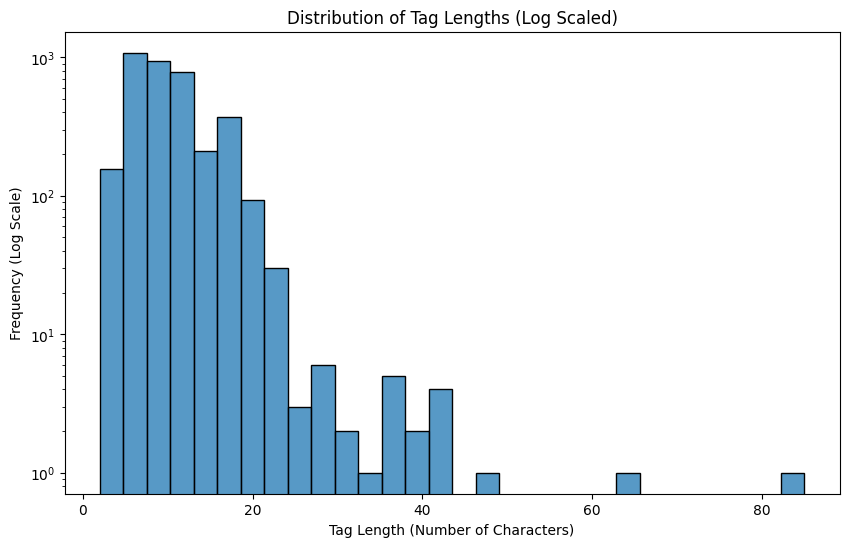

```python
plt.figure(figsize=(10,6))

ax = sns.histplot(tags['taglength'].dropna(), bins=30)

ax.set_yscale('log')

plt.title('Distribution of Tag Lengths (Log Scaled)')
plt.xlabel('Tag Length (Number of Characters)')
plt.ylabel('Frequency (Log Scale)')

plt.show()
```

### Q7:

Create a visualization that shows the average rating for each genre.

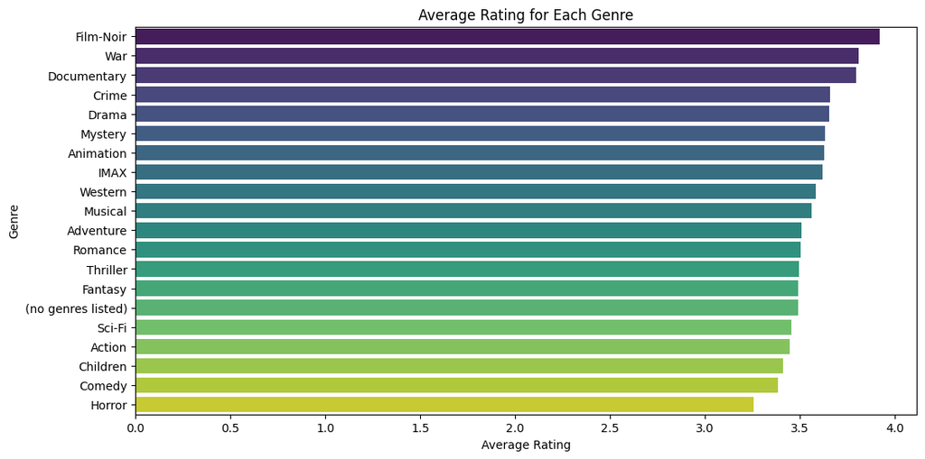

```python
movies = pd.read_csv('~/Downloads/ml-latest-small/movies.csv')
ratings = pd.read_csv('~/Downloads/ml-latest-small/ratings.csv')


merged_df = pd.merge(movies, ratings, on='movieId')

merged_df['genres'] = merged_df['genres'].str.split('|')
exploded_df = merged_df.explode('genres')

average_ratings = exploded_df.groupby('genres')['rating'].mean().reset_index()

plt.figure(figsize=(12,6))
sns.barplot(x='rating', y='genres', data=average_ratings.sort_values('rating', ascending=False), palette='viridis')

plt.title('Average Rating for Each Genre')
plt.xlabel('Average Rating')
plt.ylabel('Genre')
plt.show()
```

### Q8:

Create a visualization that shows the distribution of the **number** of ratings of "good" movies (i.e., those with a mean rating of 3.5 or highter) and "bad" movies (i.e., those with a mean rating of less than 3.5), broken down by the decade when the movie was released.

**Hint:** You will need to join the `movies` and `ratings` DataFrames to get the decade information.

**Hint:** You may want to create a box plot or a violin plot (or both).

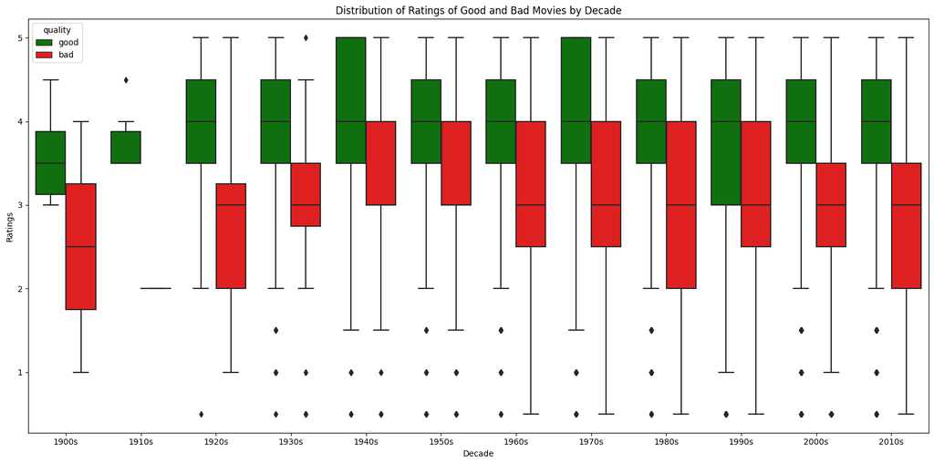

```python
movies = pd.read_csv('~/Downloads/ml-latest-small/movies.csv')
ratings = pd.read_csv('~/Downloads/ml-latest-small/ratings.csv')

movies['year'] = movies['title'].str.extract(r'\((\d{4})\)')
movies.dropna(subset=['year'], inplace=True)
movies['year'] = movies['year'].astype(int)
movies['decade'] = (movies['year'] // 10 * 10).astype(str) + 's'

decade_order = ['1900s', '1910s', '1920s', '1930s', '1940s', '1950s', '1960s', '1970s', '1980s', '1990s', '2000s', '2010s']

merged_df = movies.merge(ratings, on='movieId')

merged_df = merged_df[merged_df['decade'].isin(decade_order)]

average_rating = merged_df.groupby('movieId')['rating'].mean().reset_index(name='average_rating')
average_rating['quality'] = average_rating['average_rating'].apply(lambda x: 'good' if x >= 3.5 else 'bad')

merged_df = merged_df.merge(average_rating, on='movieId')

plt.figure(figsize=(16, 8))
sns.boxplot(x='decade', y='rating', hue='quality', data=merged_df, palette={'good': 'green', 'bad': 'red'}, order=decade_order)
plt.title('Distribution of Ratings of Good and Bad Movies by Decade')
plt.xlabel('Decade')
plt.ylabel('Ratings')
plt.tight_layout()
plt.show()
```

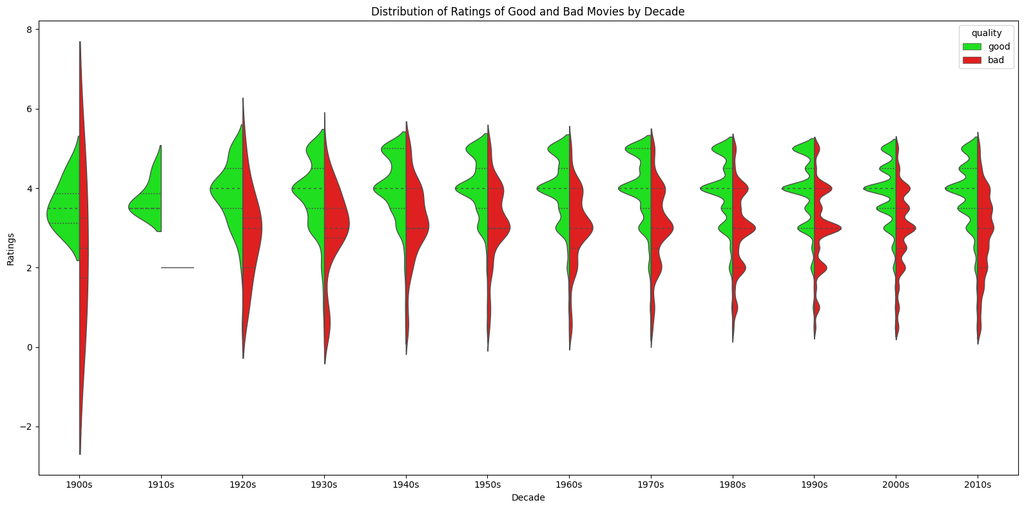

```python
movies = pd.read_csv('~/Downloads/ml-latest-small/movies.csv')
ratings = pd.read_csv('~/Downloads/ml-latest-small/ratings.csv')

movies['year'] = movies['title'].str.extract(r'\((\d{4})\)')
movies.dropna(subset=['year'], inplace=True)
movies['year'] = movies['year'].astype(int)
movies['decade'] = (movies['year'] // 10 * 10).astype(str) + 's'

decade_order = ['1900s', '1910s', '1920s', '1930s', '1940s', '1950s', '1960s', '1970s', '1980s', '1990s', '2000s', '2010s']

merged_df = movies.merge(ratings, on='movieId')

merged_df = merged_df[merged_df['decade'].isin(decade_order)]

average_rating = merged_df.groupby('movieId')['rating'].mean().reset_index(name='average_rating')
average_rating['quality'] = average_rating['average_rating'].apply(lambda x: 'good' if x >= 3.5 else 'bad')

merged_df = merged_df.merge(average_rating, on='movieId')

plt.figure(figsize=(16, 8))
sns.violinplot(x='decade', y='rating', hue='quality', data=merged_df, split=True, inner='quart', linewidth=1, palette={'good': 'lime', 'bad': 'red'}, order=decade_order)
plt.title('Distribution of Ratings of Good and Bad Movies by Decade')
plt.xlabel('Decade')
plt.ylabel('Ratings')
plt.tight_layout()
plt.show()
```